# EAI Practicum 2.4

# Understanding of the ROC curves

The goal of this exercise is to find the optimal cutoff point for classification of the defaulters and the non-defaulters. The method of choice will be the **linear discriminant analysis (LDA)**.

The key tasks of this exercise is to:

- Prepare data for the LDA
- Apply the LDA onto the dataset a visualize the outcome
- Learn how to estimate the best cut-off for classification methods automatically by researching receiver operating characteristics, ROC.

## Motivation for LDA

LDA shines if there is substantial separation (aka clear water) between the two classes because the parameter estimates for the logistic regression model become unstable. Moreover, LDA is more precise when the distribution of the predictors is approximately normal in each of the classes and the sample size is small.

For the tasks below you will need libraries **MASS** (LDA library), **ROCit** (ROC curves library), **pROC** (library for ROC calculations), **caret** (library for the confusion matrix) and **cutpointr** (to find the optimal cutoff point). The magrittr and tidyverse library is a must-have.

**Task 1:** Load the credit dataset Default.csv (you will find it on the server). Think about the dataset. Does balance values fulfills all requirement for LDA? Which test would you chose to compare the distributions of balance values between defaulters and non-defaulters? How would you modify the data to be ready for using in your LDA model?

```r
# libraries
library(tidyverse)
library(magrittr)
library(MASS)
library(ROCit)
library(pROC)
library(caret)
library(cutpointr)

# Read data into R
data <- read_csv("C:/FIIT_OZNAL/data/Default.csv", col_names = TRUE, num_threads = 4)
# Check that data are properly loaded
data
```

```
## # A tibble: 10,000 × 4
##    default student balance income
##    <chr>   <chr>     <dbl>  <dbl>
##  1 No      No         730. 44362.
##  2 No      Yes        817. 12106.
##  3 No      No        1074. 31767.
##  4 No      No         529. 35704.
##  5 No      No         786. 38463.
##  6 No      Yes        920.  7492.
##  7 No      No         826. 24905.
##  8 No      Yes        809. 17600.
##  9 No      No        1161. 37469.
## 10 No      No           0  29275.
## # ℹ 9,990 more rows
```

```r
# One-hot encoding (we can not use Yes/No)
# default
data$default <- ifelse(data$default == "Yes", 1, 0)
# student
data$student <- ifelse(data$student == "Yes", 1, 0)

# Converting to binary variables to factors
data %<>% mutate(default = as_factor(default))
data %<>% mutate(student = as_factor(student))
data
```

```
## # A tibble: 10,000 × 4
##    default student balance income
##    <fct>   <fct>     <dbl>  <dbl>
##  1 0       0          730. 44362.
##  2 0       1          817. 12106.
##  3 0       0         1074. 31767.
##  4 0       0          529. 35704.
##  5 0       0          786. 38463.
##  6 0       1          920.  7492.
##  7 0       0          826. 24905.
##  8 0       1          809. 17600.
##  9 0       0         1161. 37469.
## 10 0       0            0  29275.
## # ℹ 9,990 more rows
```

## Exploratory Descriptive Analysis

**Task 2:** Analyze the data you want to classify? How does the defaulters and the non-defaulters groups look like? What inferences do you draw from your analysis?

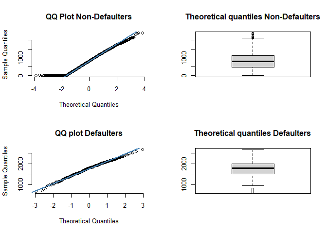

As obvious from the graphs, the analyses show an enrichment of clients with 0 account balance. It is debatable, whether include them in the analysis, or omit them completely from LDA. They will impact LDA but not logistic regression because LDA uses central tendencies and standard deviation for calculations, and these are likely to be skewed by disproportionately distributed data.

**LDA is sensitive for data that are not only being normally distributed, but also expects that observations in both groups have exactly the same shape of the bell curve.** In other words, they have the same variance. This is not the case for default data and this would be place to acknowledge it.

## Linear discriminant analysis

**Task 3.:** Create the LDA model and make the prediction object. Fill-in the missing parts of the code.

```r
# LDA model
model_lda <- lda(default ~ balance, data = data)
model_lda

# LDA prediction
lda_predict <- predict(object = model_lda)

# mining lda_predict object
str(lda_predict)
head(lda_predict$class)
head(lda_predict$posterior) # Extract sigma hat values for each class
```

**Task 4.:** Analyze the structure of the prediction object. What does it tell you?

```
## Call:
## lda(default ~ balance, data = data)
##
## Prior probabilities of groups:
##      0      1
## 0.9667 0.0333
##
## Group means:
##     balance
## 0  803.9438
## 1 1747.8217
##
## Coefficients of linear discriminants:
##                 LD1
## balance 0.002206916
```

```
## List of 3
##  $ class    : Factor w/ 2 levels "0","1": 1 1 1 1 1 1 1 1 1 1 ...
##  $ posterior: num [1:10000, 1:2] 0.997 0.996 0.987 0.999 0.996 ...
##   ..- attr(*, "dimnames")=List of 2
##   .. ..$ : chr [1:10000] "1" "2" "3" "4" ...
##   .. ..$ : chr [1:2] "0" "1"
##  $ x        : num [1:10000, 1] -0.2336 -0.0402 0.5256 -0.6756 -0.1097 ...
##   ..- attr(*, "dimnames")=List of 2
##   .. ..$ : chr [1:10000] "1" "2" "3" "4" ...
##   .. ..$ : chr "LD1"
```

```
## [1] 0 0 0 0 0 0
## Levels: 0 1
```

```
##           0           1
## 1 0.9972130 0.002786981
## 2 0.9958358 0.004164240
## 3 0.9865931 0.013406929
## 4 0.9988882 0.001111757
## 5 0.9963955 0.003604464
## 6 0.9933487 0.006651334
```

## Receiver operating characteristics

The default cut-off for logistic regression might not reflect the best cut-off possible. Hence, comparing the 0.5 cut-off to LDA does not make sense (although this is what most people do in their diploma theses). If you are to make the real comparison of two classification methods, best you chose the cut-offs that are the most optimal for each method. For most problems this will be something like the Younden index, which you won’t find by testing multiple cut-offs manually. You have to find it systematically, and that is what receiver operating characteristics, or ROC, do.

This is how your distributions look like on the graph. The blue line represents the optimal cut-off. But how to find it?

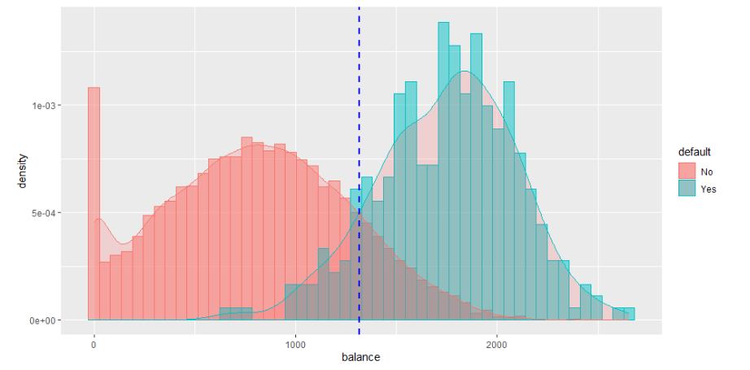

To find the best cut-off for one or more classification methods, you need to construct the receiver operating characteristics (ROC) curve for each method and then find the point on that curve that is most top left. The method that can make it closer to the top left corner wins.

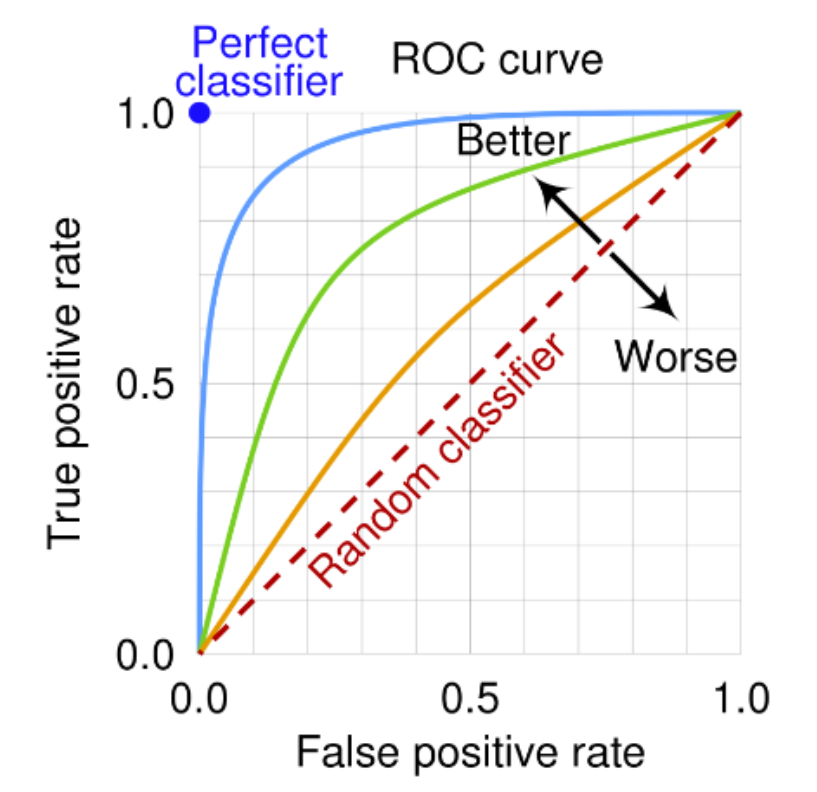

ROC curve represents the optimal trade-off between True positive rate (TPR) and False positive rate (FPR). That is, the best trade of between identifying as many true defaulters whilst miss-classifying as few non-defaulters. It is plotted as a curve that comes from an iterative calculation of TPR and FPR, starting from a single defaulter with the highest balance, then adding the defaulter with the second highest balance to the set (containing just the first defaulters at this point) and so on.

## ROCit : best for model comparison

Let’s start with ROCit, which is a good package for ROC plotting and offers some interesting data along the way. You can install the package with install.packages(“ROCit”). The ROC creation will be carried out in a single step, assuming that you have logistic regression model available as an object. If not, let’s start from the beginning.

To see the ROC curve you can use the rocit() function, which creates the ROC object that can be passed to the **plot()** and **ksplot()** function.

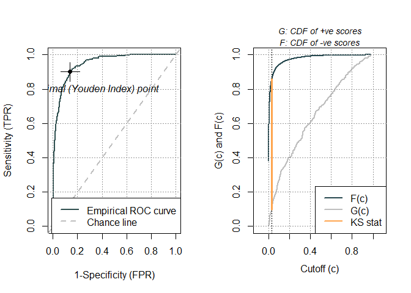

```r
model_glm <- glm(default ~ balance, data = data, family = binomial)

library(ROCit)
roc <- rocit(class = model_glm$y,
             score = model_glm$fitted.values)

par(mfrow = c(1,2))
plot(roc)
ksplot(roc)
```

**However, to get the measure of AUC (the area under the curve) you have to perform summary()**

```r
summary(roc)
```

```
##
##  Method used: empirical
##  Number of positive(s): 333
##  Number of negative(s): 9667
##  Area under curve: 0.948
```

**The higher number is the better.** AUC provides an aggregate measure of performance across all possible classification thresholds. One way of interpreting AUC is as the probability that the model ranks a random positive example more highly than a random negative example. It is also important to remember that

- **AUC is scale-invariant**. It measures how well predictions are ranked, rather than their absolute values.
- **AUC is classification-threshold-invariant**. It measures the quality of the model’s predictions irrespective of what classification threshold is chosen.

**The AUC measure is the best way how to tell which classification method is better.** Compare the outcome of the logistic regression and the LDA using ROC curves. However, there are better libraries to mine the data than ROCit…

## pROC: best for data mining

```r
library(pROC)
pROC <- pROC::roc(data$default, data$balance, algorithm = 2)
```

It is not particularly graphically appealing even if you plot the object. However, the wealth data are good when you want to dig in. For example, which balance values corresponds the best cut-off you can get from logistic regression? For those questions, we can use other functions packed within pROC.

```r
pROC_results <- coords(pROC, "local maximas", ret=c("threshold", "sens", "spec",
                                          "ppv", "npv", "youden", "closest.topleft"))
head(pROC_results)
tail(pROC_results)
```

```
##   threshold sensitivity specificity        ppv       npv   youden
## 1  652.3849    1.000000   0.3807800 0.05269821 1.0000000 1.380780
## 2  698.5398    0.996997   0.4153305 0.05548128 0.9997510 1.412328
## 3  779.9149    0.993994   0.4818455 0.06198502 0.9995708 1.475839
## 4  959.1111    0.990991   0.6266680 0.08377761 0.9995050 1.617659
## 5  961.4805    0.987988   0.6284266 0.08390717 0.9993420 1.616415
## 6  961.6541    0.984985   0.6285301 0.08369482 0.9991778 1.613515
##   closest.topleft
## 1       0.3834334
## 2       0.3418474
## 3       0.2685202
## 4       0.1394579
## 5       0.1382111
## 6       0.1382154
```

```
##     threshold sensitivity specificity       ppv       npv   youden
## 214  2134.475  0.11411411   0.9993793 0.8636364 0.9703696 1.113493
## 215  2152.313  0.10210210   0.9994828 0.8717949 0.9699829 1.101585
## 216  2218.648  0.06606607   0.9995862 0.8461538 0.9688189 1.065652
## 217  2315.388  0.03903904   0.9996897 0.8125000 0.9679487 1.038729
## 218  2378.889  0.02402402   0.9997931 0.8000000 0.9674675 1.023817
## 219  2402.164  0.02102102   1.0000000 1.0000000 0.9673772 1.021021
##     closest.topleft
## 214       0.7847942
## 215       0.8062209
## 216       0.8722328
## 217       0.9234461
## 218       0.9525291
## 219       0.9583998
```

**Task 6.:**Think how can the resulting data frame be used to find the maximal value for the “top left” or Youden and how would you pair that information with the information about balance values and probabilities you have. This should be relatively easy and doable with the knowledge that you already have.

```r
max_youden <- max(pROC_results$youden)
max_youden
```

```
## [1] 1.760526
```

## cutpointr - the easiest way to get cutoff point

The cutpointr library gives you the exact optimal cutpoint along with the multitude of other measurements.

```
## Assuming the positive class is 1
```

```
## Assuming the positive class has higher x values
```

```
## Method: maximize_metric
## Predictor: balance
## Outcome: default
## Direction: >=
##
##    AUC     n n_pos n_neg
##  0.948 10000   333  9667
##
##  optimal_cutpoint sum_sens_spec   acc sensitivity specificity  tp fn   fp   tn
##          1315.559        1.7605 0.861      0.9009      0.8596 300 33 1357 8310
##
## Predictor summary:
##     Data     Min.           5%   1st Qu.    Median      Mean  3rd Qu.      95%
##  Overall   0.0000    0.4246597  481.7311  823.6370  835.3749 1166.308 1665.963
##        0   0.0000    0.0000000  465.7146  802.8571  803.9438 1128.249 1569.803
##        1 652.3971 1140.2272417 1511.6110 1789.0934 1747.8217 1988.870 2265.088
##      Max.       SD NAs
##  2654.323 483.7150   0
##  2391.008 456.4762   0
##  2654.323 341.2668   0
```

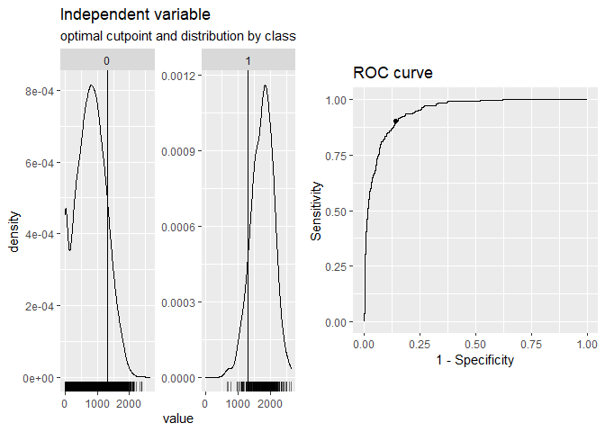

```r
library(cutpointr)

cp <- cutpointr(data, balance, default, method = maximize_metric, metric = sum_sens_spec)
summary(cp)
plot(cp)
```

**Task 7.:** Think about the optimal cutoff point. What does it tell you? Is the optimal cutoff always optimal? How does it go with your goals?